# Session 2: Model Validation and Prediction

# Introduction

Today’s session is focused on the prediction process. It’s really easy to make a prediction. It’s really hard to get it right.

[figure not shown]

By the end of today’s session, we will have covered:

- What steps you can take to make sure you have a good prediction through *model validation*
- How to balance interpretability with accuracy
- What are the different prediction methods that you can use

# Setting up the data

We’ll borrow some basic data from the Quarterly Services Survey and see if we can predict services sector growth. Before we start, let’s load in the data, which is a long-form data set of quarterly growths:

- *growth*: Growth by industry from the Census Quarterly Services Survey
- *ces*: by employment level by industry from the BLS Current Employment Survey
- *google*: search query volume from Google Trends
- *cpi*: by consumer price index

The version of the data we’re using is all publicly available, scraped from web sources. In total, the data contains $n = 55$, which covers the great recession, with $k = 793$ variables for 20 industries. There are three other data frames available in this data set, but we just need to worry about *qss_main*.

```r
#LOAD DATA
  load("example.Rda")
  dim(qss_main)
```

```
## [1] 1096  796
```

For now let’s just focus on one industry: *NAICS 511 - Publishing Industries (except internet)*. We can subset the industry by using row index notation.

```r
#SET UP DATA
  short <- qss_main[qss_main$naics == "511",]
```

For some context, we’ll create a vector that flags when the recession took place.

```r
#Create vector
  recession <- rep(0, nrow(short))
  recession[short$period %in% c("2007-Q4", "2008-Q1", "2008-Q2",
                                "2008-Q3", "2008-Q4",
                                "2009-Q1", "2009-Q2")] <- 1

#Define the dimensions of a box to highlight recession in a graph
  xleft <- which(recession == 1)[1]
  xright <- which(recession == 1)
  xright <- max(xright)
  ytop = max(short$growth) + 1
  ybottom = min(short$growth) - 11
```

Then, plot the data to show that they are seasonal and dip during the recession.

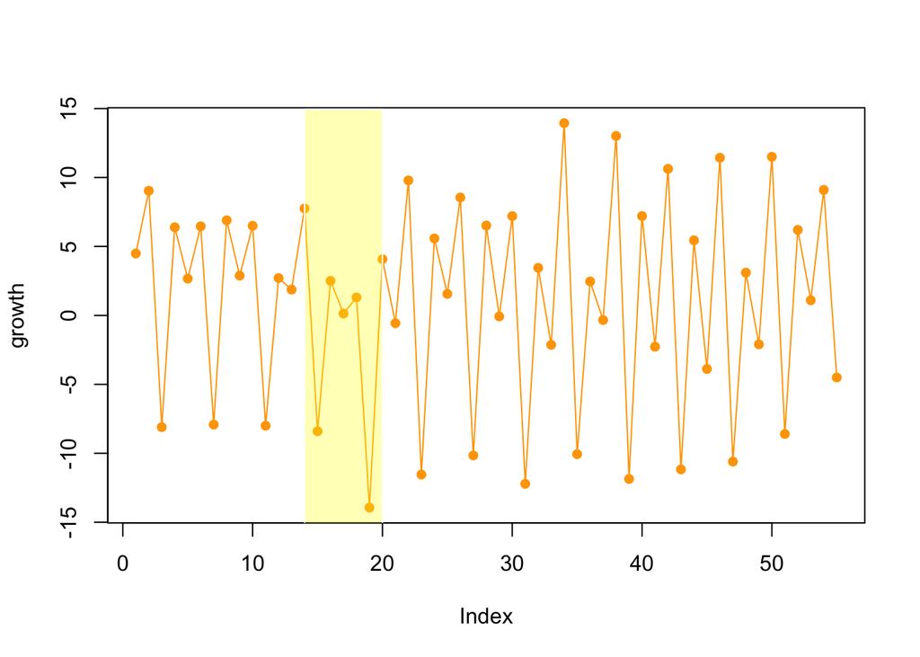

```r
  plot(short$growth, type = "l", ylab = "growth", col = "orange")
  points(short$growth, col = "orange", pch = 16)
  rect(xleft, ybottom, xright, ytop,
       col = rgb(1,1,0,0.3),
       border = FALSE)
```

# Refresher

Prediction relies on the idea of *supervised learning*. Basically:

$$y = f(x)$$

indicates that we have some set of input variables $x$ that are mapped using some function $f$ to mimic a target variable $y$. It is called supervised as an algorithm has a specific goal or target to meet, doing so by learning the pattern between $y$ and $x$. The algorithm can take any data in the same structure and format as $x$, then produce a prediction $\hat{y}$. Prediction and forecasting are thus the same thing – an algorithm learns the patterns then applies it.

In time series, certain behaviors are expected of the data. In particular, we want to see data that are *stationary* – or data in which the mean, variance and autocorrelation are constant over time. In other words, if we can ensure that the statistical properties of the data are “tame” and predictable, any paradigm we identify through modeling is generalizable. The series should not be floating off to oblivion uncontrollably, but rather should stay relatively stable wthin certain bounds.

[figure not shown]

### How do you know if something is stationary?

Check the *autocorrelation function* and *partial autocorrelation function*. The lags should drop off quickly if the series is stationary. Easy way to turn a non-stationary series into stationary is to take the difference using `diff()`.

**TRY THIS**

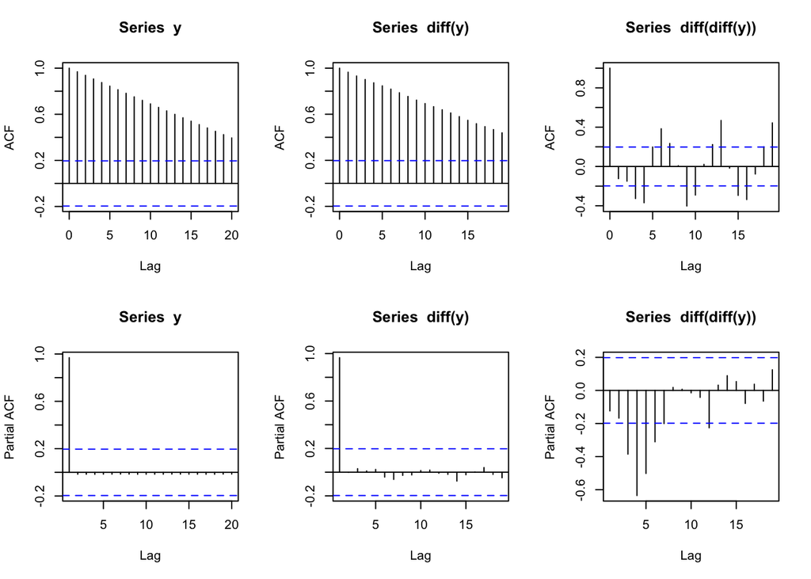

```r
#Create synthetic series
  y <- (5*sin(1:100) + runif(100)*5 + (1:100)^2)

#Plot
  par(mfrow = c(2,3))

#Autocorrelation Function
  acf(y);
  acf(diff(y))
  acf(diff(diff(y)))


#Partial Autocorrelation Function
  pacf(y)
  pacf(diff(y))
  pacf(diff(diff(y)))
```

Then also the Augmented Dickey Fuller test that tests for unit roots where the null hypothesis is that there is a presence of a unit root.

```r
  library(tseries)
  adf.test(y)
```

```
##
##  Augmented Dickey-Fuller Test
##
## data:  y
## Dickey-Fuller = -0.29186, Lag order = 4, p-value = 0.9894
## alternative hypothesis: stationary
```

```r
  adf.test(diff(y))
```

```
##
##  Augmented Dickey-Fuller Test
##
## data:  diff(y)
## Dickey-Fuller = -13.555, Lag order = 4, p-value = 0.01
## alternative hypothesis: stationary
```

```r
  adf.test(diff(diff(y)))
```

```
##
##  Augmented Dickey-Fuller Test
##
## data:  diff(diff(y))
## Dickey-Fuller = -14.683, Lag order = 4, p-value = 0.01
## alternative hypothesis: stationary
```

The function $f$ can take on a number of forms, but today we’ll cover two principal types:

- **Linear regression** assumes that the the target is linearly associated with the inputs subject to a constraint. Common examples include *ordinary least squares* (OLS) and *Least Absolute Shrinkage and Selection Operator* (LASSO).
- **Tree-Based Learning** partition samples into smaller and smaller more homogeneous subsamples – basically a combination of characteristics define a cell of observations that take on an average value of the outcome. Common examples include *regression trees* and *random forests*.

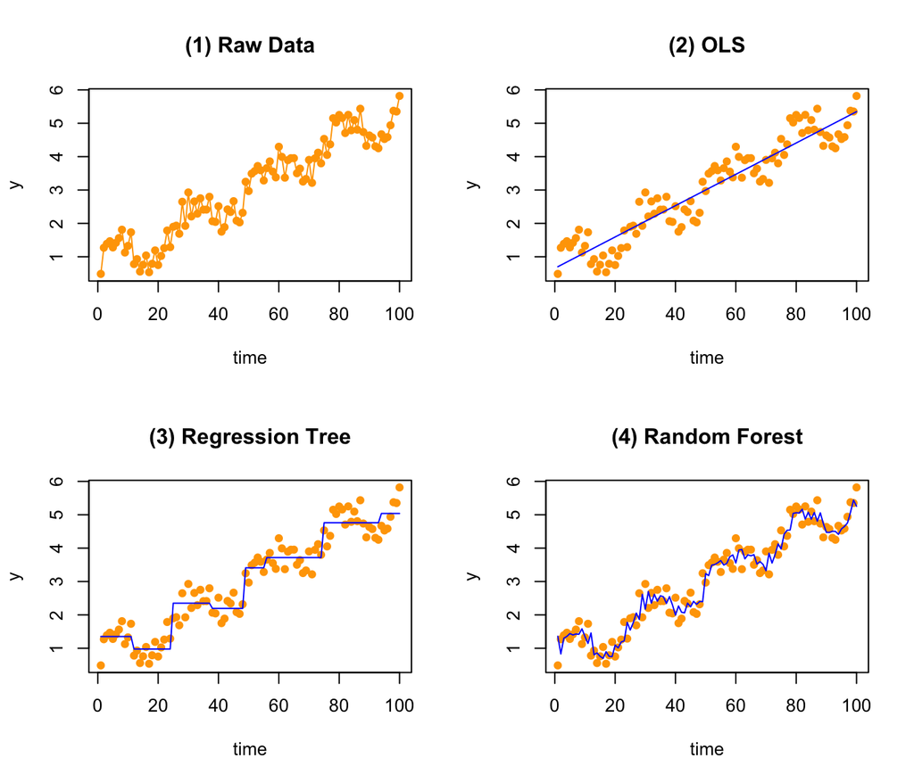

## Linear Regression

OLS regression is the quantitative workhorse in most fields. The technique is a statistical method that estimates unknown parameters by minimizing the sum of squared differences between the observed values and predicted values of the target variable. To better understand arguably the most commonly used supervised learning method, we can start by defining a regression formula:

$$y_i = \beta_0 x_{i,0} + \beta_{1} x_{i,1} + ... + \beta_{k} \beta_{i,k} + \epsilon_{i}$$

where:

- $y_i$ is the target variable or “observed response”
- $\beta_{k}$ are coefficients associated with each $x_k$. Each coefficient can be obtained by solving $\hat{\beta} = (X'X)^{-1}X'Y$. Note that $w$ may be substituted with $\beta$ in some cases.
- $x_{i,k}$ are input or independent variables
- subscript $i$ indicates the index of individual observations in the data set
- $k$ is an index of position of a variable in a matrix of $x$
- $\epsilon_{i}$ is an error term that is assumed to have a normal distribution of $\mu = 0$ and constant variance $\sigma^2$

# Model Validation

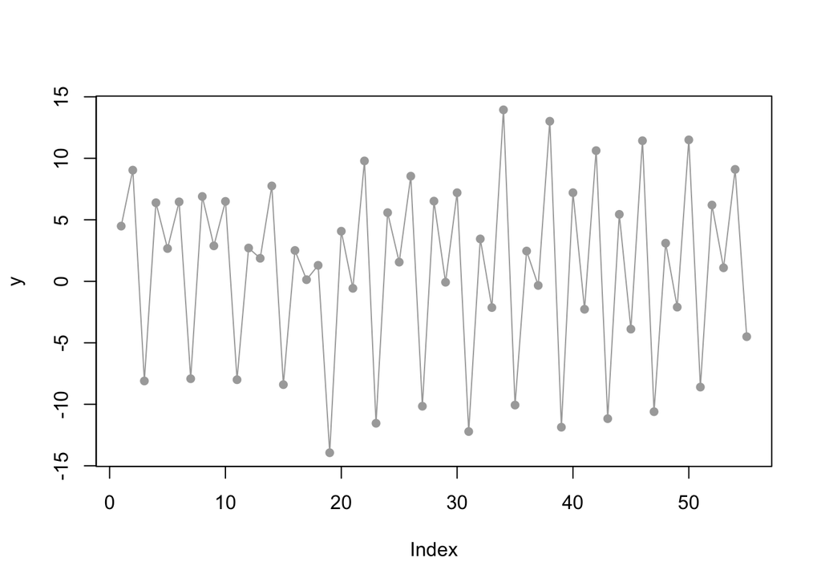

```r
  #MODEL VALIDATION

  #Example of overconfidence
  #Cut out data
  y <- short$growth
  x <- as.matrix(short[,4:ncol(short)])

  #Plot for example
  plot(y, pch = 16, col = "darkgrey")
  lines(y, col = "darkgrey")
```

```r
  #Overfit for GLMNET and plot
  library(glmnet)
  fit <- cv.glmnet(x, y, alpha = 1)

  coef.cv.glmnet(fit, s = "lambda.min" )
```

```
## 794 x 1 sparse Matrix of class "dgCMatrix"
##                        1
## (Intercept)  0.689777139
## ces1         .
## ces2         .
## ces3         .
## ces4         0.338037622
## ces5         .
## ces6         .
## ces8         .
## ces9         .
## ces10        .
## ces14        .
## ces16        .
## ces17        .
## ces20        .
## ces25        .
## ces30        .
## ces31        .
## ces32        .
## ces36        .
## ces41        .
## ces47        .
## ces56        .
## ces64        .
## ces70        .
## ces75        .
## ces82        .
## ces86        .
## ces89        .
## ces90        .
## ces100       .
## ces102       .
## ces105       .
## ces108       .
## ces111       .
## ces113       .
## ces115       .
## ces123       .
## ces129       .
```

[output cut: 741 more lines]

```
## cpi73        .
## cpi74        .
## cpi75        .
## cpi76        .
## cpi77        .
## cpi78        .
## cpi79        .
## cpi80        .
## cpi81        .
## cpi82        1.590466309
## cpi83        .
## cpi84        .
## cpi85        .
## cpi86        .
## cpi87        .
```

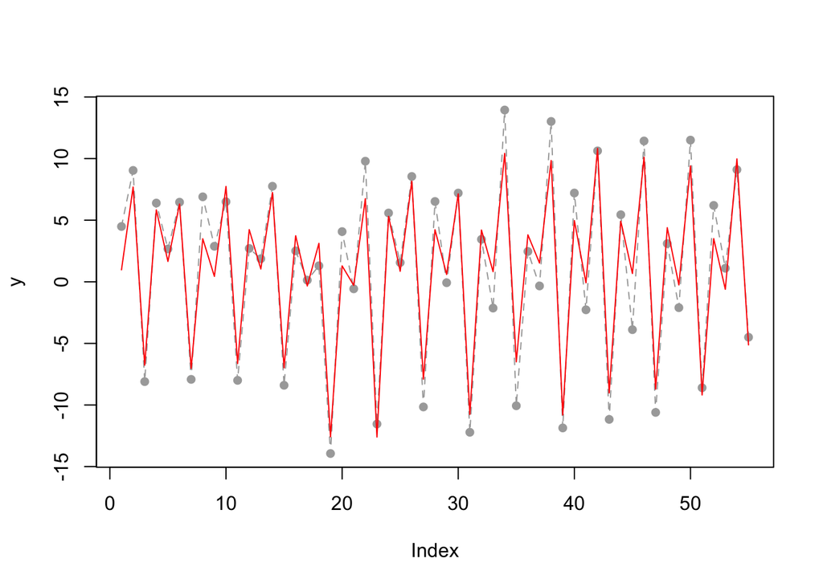

```r
  yhat_1 <- predict(fit, x, s = "lambda.min")

  plot(y, pch = 16, col = "darkgrey")
  lines(y, col = "darkgrey", lty = "dashed")
  lines(yhat_1, col = "red")
```

```r
  #Example 1: Train/Test
  test.start <- 15
  fit <- cv.glmnet(x[1:(test.start-1),], y[1:(test.start-1)], alpha = 1)
  coef.cv.glmnet(fit, s = "lambda.min" )
```

```
## 794 x 1 sparse Matrix of class "dgCMatrix"
##                        1
## (Intercept)  2.130319206
## ces1         .
## ces2         .
## ces3         .
## ces4         .
## ces5         .
## ces6         .
## ces8         .
## ces9         .
## ces10        .
## ces14        .
## ces16        .
## ces17        .
## ces20        .
## ces25        .
## ces30        .
## ces31        0.777649845
## ces32        .
## ces36        .
## ces41        .
## ces47        .
## ces56        .
## ces64        .
## ces70        .
## ces75        .
## ces82        .
## ces86        .
## ces89        .
## ces90        .
## ces100       .
## ces102       .
## ces105       .
## ces108       .
## ces111       0.011764634
## ces113       .
## ces115       .
## ces123       .
## ces129       0.874544384
```

[output cut: 741 more lines]

```
## cpi73        .
## cpi74        .
## cpi75        .
## cpi76        .
## cpi77        .
## cpi78        .
## cpi79        .
## cpi80        .
## cpi81        .
## cpi82        .
## cpi83        .
## cpi84        .
## cpi85        .
## cpi86        .
## cpi87        .
```

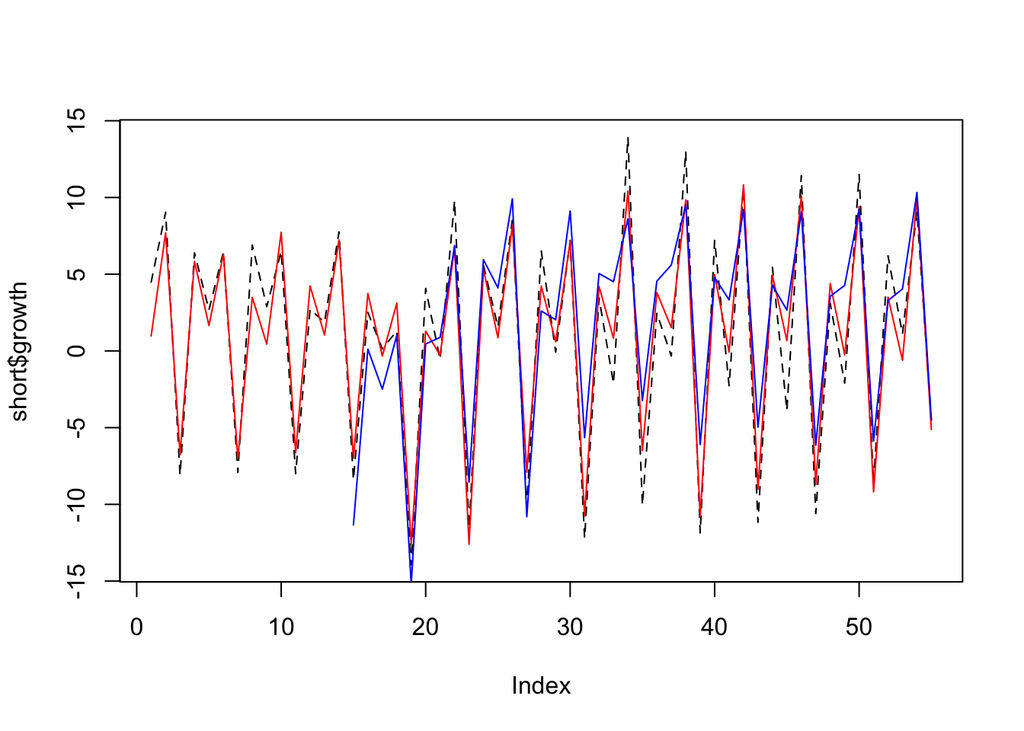

```r
  yhat_2 <- predict(fit, x, s = "lambda.min")
  plot(short$growth, type = "l", lty = "dashed")
  lines(yhat_1, col = "red")
  lines(c(rep(NA, (test.start-1)),yhat_2[test.start:length(y)]), col = "blue")
```

```r
  plot(y, pch = 16, col = "darkgrey")
  lines(y, col = "darkgrey", lty = "dashed")
  lines(yhat_1, col = "red")
  lines(c(rep(NA, (test.start-1)),yhat_2[test.start:length(y)]), col = "blue")

  #Example 2: One Step Ahead (Chaining)

  yhat_3 <- yhat_2

  for(i in test.start:length(y)){
    fit <- cv.glmnet(x[1:(test.start-1),], y[1:(test.start-1)], alpha = 1)

    temp <- predict(fit,x, s = "lambda.min")
    yhat_3[i] <- temp[i]
  }
```

[output not shown]

[output cut: 67 more lines]

[output not shown]

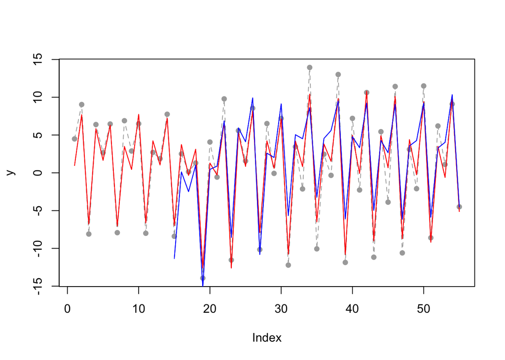

```r
  lines(yhat_1, col = "red")
  lines(c(rep(NA, (test.start-1)),yhat_2[test.start:length(y)]), col = "blue")
```

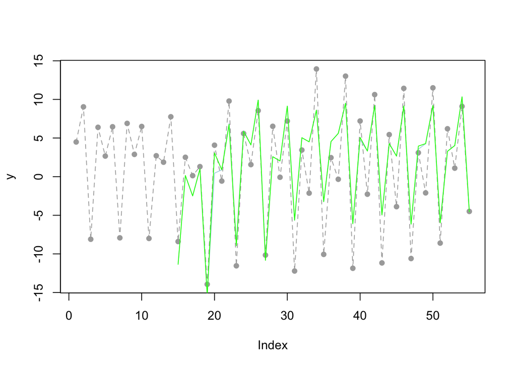

```r
  plot(y, pch = 16, col = "darkgrey")
  lines(y, col = "darkgrey", lty = "dashed")
  # lines(yhat_1, col = "red")
  lines(c(rep(NA, (test.start-1)),yhat_2[test.start:length(y)]), col = "lightblue")
  lines(c(rep(NA, (test.start-1)),yhat_3[test.start:length(y)]), col = "green")
```

```r
  sqrt(mean((yhat_2-y)^2, na.rm = T))
```

```
## [1] 3.185012
```

```r
  sqrt(mean((yhat_3-y)^2, na.rm = T))
```

```
## [1] 3.143252
```

```r
#ALGORITHMS

  #Create time series object
    qss <- ts(short[,3:ncol(short)], start = c(2004,3), frequency = 4)

  #ARIMA
  # Assumes regularity and momentum
  # Stationary processes
  # Linearity
    library(forecast)
```

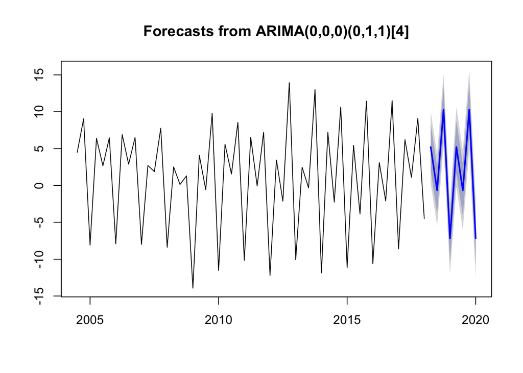

```r
    fit <- auto.arima(y = qss[,1],
                      seasonal = TRUE)

    #Apply regression model to out-of-sample set
    out <- forecast(fit)
    plot(out)
```

```r
  #GLMNET
    library(glmnet)

    #LASSO
    fit <- cv.glmnet(x = as.matrix(qss[,-1]),
                     y = as.vector(qss[,1]),
                     alpha = 1)
    coef.cv.glmnet(fit, s = "lambda.min" )
```

```
## 794 x 1 sparse Matrix of class "dgCMatrix"
##                         1
## (Intercept)  1.5358318576
## ces1         .
## ces2         .
## ces3         .
## ces4         0.3448533832
## ces5         .
## ces6         .
## ces8         .
## ces9         .
## ces10        .
## ces14        .
## ces16        .
## ces17        .
## ces20        .
## ces25        .
## ces30        .
## ces31        .
## ces32        .
## ces36        .
## ces41        .
## ces47        .
## ces56        .
## ces64        .
## ces70        .
## ces75        .
## ces82        .
## ces86        .
## ces89        .
## ces90        .
## ces100       .
## ces102       .
## ces105       .
## ces108       .
## ces111       .
## ces113       .
## ces115       .
## ces123       .
## ces129       0.0026016093
```

[output cut: 741 more lines]

```
## cpi73        .
## cpi74        .
## cpi75        .
## cpi76        .
## cpi77        .
## cpi78        .
## cpi79        .
## cpi80        .
## cpi81        .
## cpi82        2.6337985217
## cpi83        .
## cpi84        .
## cpi85        .
## cpi86        .
## cpi87        .
```

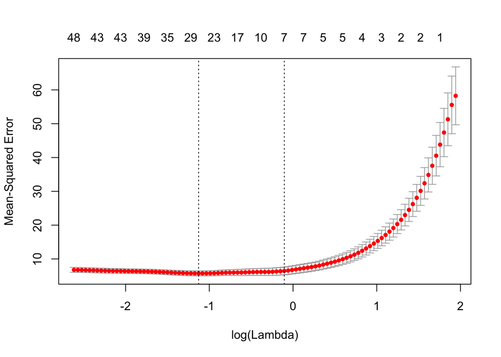

```r
    plot(fit)
```

```r
  #Decision Trees

    library(rpart)
    fit <- rpart(growth ~., data = qss, cp = 0)
    printcp(fit)
```

```
##
## Regression tree:
## rpart(formula = growth ~ ., data = qss, cp = 0)
##
## Variables actually used in tree construction:
## [1] ces129 ces153 ces163
##
## Root node error: 3043.8/55 = 55.341
##
## n= 55
##
##         CP nsplit rel error  xerror     xstd
## 1 0.718395      0  1.000000 1.05121 0.147843
## 2 0.153121      1  0.281605 0.32291 0.055711
## 3 0.038201      2  0.128484 0.28079 0.045666
## 4 0.000000      3  0.090283 0.24998 0.053818
```

```r
    #Choose best
    best <- which(fit$cptable[,4] == min(fit$cptable[,4]))
    best.cp <- fit$cptable[best,1]
    fit <- rpart(growth ~., data = qss, cp = best.cp)

    yhat_dt <- predict(fit, qss)
    yhat_dt <- ts(yhat_dt , start = c(2004,2), frequency = 2)

  #Random Forests
    library(randomForest)
```